# Pedigree Likelihood in R

- The genetic content of individuals from the same family is not independent of each other.
- When we want to calculate the likelihood of genetic or phenotype-genotype data collected in a family, we need to consider family structure.
  - The family structure is called “pedigree”.
- One popular algorithm to estimate the likelihood of observed data on a pedigree is the Elston-Stewart algorithm
- There are several R-Packages that implement a general purpose Elston-Stewart algorithm.
  - Today we will be using a package called “ElstonStewart” to implement a few different genetic models and calculate the likelihood of a pedigree.

### Load Environment

```r
# clean
rm(list = ls(all=TRUE))

# load
library(ElstonStewart)
```

#### Example using the ElstonStewart R-Packages and “conrad2” data set

- This family has many generations, inbreeding and loops
  - The Elston-Stewart algorithm does not work well in pedigrees with loops/inbreeding
  - Packages like the ElstonStewart or pedprobr/pedtools R-Package can deal with such complex pedigrees

### Load the conrad2 data

```r
## cf Elston-Stewart vignette for more comments on this example
data(conrad2)
```

### Add the genotype information for each family member

- In our example, we do not know the genotypes of any family member, except 1 and 22
  - This is coded by giving each family members all possible genotypes (except 1, 22)
  - 0 = homozygous wild type
  - 1 = heterozygous
  - 2 = homozygous variant

```r
# creating an es.pedigree object
conrad.genotypes <-rep(
  list(
    0:2
  ), 22
)
conrad.genotypes[[1]]=2
conrad.genotypes[[22]]=2
```

### We will make a phenotype list

- In our first model, the phenotype probability for each family member will be 1
  - We will change this when we use our custom model
- We will give a dummy phenotype to every family member

```r
# get phenotypes
conrad.phenotypes=rep(
  0,
  22
)
```

### Make the pedigree object

- The ElstonStewart R-Package uses the “es.pedigree” object
  - I believe that’s French for “it is a pedigree”

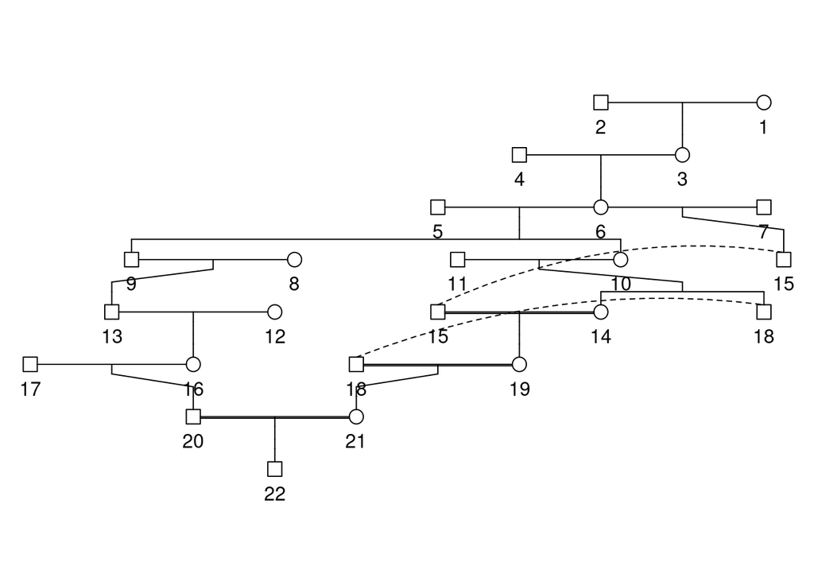

```r
# make es.pedigree object for Elston-Stewart
X <- es.pedigree(
  id = conrad2$id,
  father = conrad2$father,
  mother = conrad2$mother,
  sex = conrad2$sex,
  pheno = conrad.phenotypes,
  geno = conrad.genotypes
)
plot.es.pedigree(X)
```

### Run the Elston-Stewart algorithm using the basic di allelic model provided in the ElstonStewart R-Package

- modele.di = Models inheritance based on two alleles (as is the case for humans in somatic chromosomes)
- theta = contains the allele frequency of the “A” allele

```r
# input theta
theta=list(p=0.9)

# running Elston-Stewart
r <- Elston(
  ped = X,
  modele = modele.di,
  theta = theta
)
r$result
```

```
## [1] 0.0002160156
```

- This result shows the observed data is very unlikely, as our proband (22) has a homozygous variant phenotype, which should be very unlikely given the allele frequency we input (theta)

### Summary of what we learned

- The Elston-Stewart algorithm can calculate the likelihood of family data even in complex pedigrees.
- It is ideal on pedigrees that do not have loops/inbreeding, but packages like ElstonStewart or pedprobr/pedtools can handle inbred pedigrees.
- The algorithm needs as input:
  - allele frequency (to calculate founder genotype probabilities)
  - Mendelian rules of transmission (to get transmission probabilities)
  - Penetrance estimate/ penetrance function (to calculate phenotype probabilities give genotypes)
- On our examples, we implemented an instance of the Elston-Stewart Algorithm for the di-allelic case where phenotype probabilities are always 1.
  - The phenotype probabilities need not be 1 in every case. This can be easily adjusted by changing the phenotype probability function.
  - For example, a phenotype based on observing a particular event by age t, that can be modeled using a parametric survival analysis (for example, an exponential function), non-parametric (Kaplan-Meier estimator) or semi-parametric (Cox Proportional Hazards framework)
- We will now do a simple example of this kind of penetrance (phenotype probabilities)
- We will write our own custom model from scratch

### First, we’ll write a function to get founder probabilities

- These are the probabilities of observing a given genotype in founders
  - Founders are individuals without parents
- ‘theta$p’ is the frequency of the major allele (A allele)
- ‘g’ is the genotype of this individual
- this function is exactly the same as the one in “modele.di”, since we are still working on human data and somatic chromosomes.

```r
get.founder.probabilities.from.afreq=function(
  g,
  theta
)
{
  if(g == 0)
    {
        return(theta$p^2)
    }
  if(g == 1)
    {
      return(2 * theta$p * (1 - theta$p))
    }
  if(g == 2)
    {
      return((1 - theta$p)^2)
    }
    stop("Unknown Genotype")
}
```

### Make fuction to get the probability of the phenotypes given a genotype

- We call these penetrance
- In this example, the phenotype probability is not always equal to 1 (different from modele.di)
- The probability of observing a phenotype event by age t is exponentially distributed, with a higher rate parameter for people without variant genotype.

```r
## Make function to get penetrance probabilities based on an exponential function (will use in the future)
get.phenotype.genotype.probabilities=function(
  x,
  g,
  theta
)
{
  # get phenotype information
  phenotype.event=x[1]
  phenotype.time=x[2]

  # get probability of phenotype
  if(g==0)
  {
      if(phenotype.event==1)
    {
      p=dexp(
        x=phenotype.time,
        rate = 0.1
      )
    } else if(phenotype.event==0)
    {
      p=pexp(
        q=phenotype.time,
        rate = 0.1,
        lower.tail = FALSE
      )
    } else
      {
        warning('invalid phenotype/genotype')
      }
  } else if(g==1 | g==2)
  {
    # get probability
    if(phenotype.event==1)
    {
      p=dexp(
        x=phenotype.time,
        rate = 0.025
      )
    } else if(phenotype.event==0)
    {
      p=pexp(
        q=phenotype.time,
        rate = 0.025,
        lower.tail = FALSE
      )
    } else
      {
        warning('invalid phenotype/genotype')
      }
  }
  return(p)
}
```

### Make function to get transmission probabilities

- These are the probabilities of observing a genotype in the offspring given the genotypes of both parents
- They are derived from Mendel’s rules of inheritance
- This function works the same as the transmission probabilities in modele.di, as we are still in the di-allelic setting with somatic chromosomes.

```r
get.transmission.probabilities=function(
  of,
  fa,
  mo
)
{
    if (fa == 0)
    {
        if (mo == 0 & of == 0)
            return(1)
        if (mo == 1 & (of == 0 | of == 1))
            return(0.5)
        if (mo == 2 & of == 1)
            return(1)
    }
    if (fa == 1)
    {
        if (mo == 0 & (of == 0 | of == 1))
            return(0.5)
        if (mo == 1 & (of == 0 | of == 2))
            return(0.25)
        if (mo == 1 & of == 1)
            return(0.5)
        if (mo == 2 & (of == 1 | of == 2))
            return(0.5)
    }
    if (fa == 2)
    {
        if (mo == 0 & of == 1)
            return(1)
        if (mo == 1 & (of == 1 | of == 2))
            return(0.5)
        if (mo == 2 & of == 2)
            return(1)
    }
    return(0)
}
```

### Make a new modele object for ElstonStewart R-Package

```r
new.modele = list(
  'name' = 'CCVR.Modele',
  'proba.g' = get.founder.probabilities.from.afreq,
  'trans' = get.transmission.probabilities,
  'p.pheno' = get.phenotype.genotype.probabilities
)
```

### Make the phenotype information appropriate for our model

- No family member has event by age 60, except individual 22, who had event at 35

```r
# give phenotype with events to many family members
conrad.phenotypes = rep(
  list(c(0,60)),
  22
)
conrad.phenotypes[[22]]=c(1,35)
```

### Run the Elston-Stewart algorithm using the ElstonStewart R-Package with our custom model

```r
# make es.pedigree object for Elston-Stewart
Our.Pedigree <- es.pedigree(
  id = conrad2$id,
  father = conrad2$father,
  mother = conrad2$mother,
  sex = conrad2$sex,
  pheno = conrad.phenotypes,
  geno = conrad.genotypes
)

# running Elston-Stewart
r <- Elston(
  ped = Our.Pedigree,
  modele = new.modele,
  theta = theta
)
r$result
```

```
## [1] 7.523996e-25
```

- As you can see, our probabilities changed, which makes sense since our model changed.
- Now, lets see how the probabilities change if we change the genotype and phenotype information.

### Make example where many family members have early events

```r
# make most famly members have genotype 1 or 2
conrad.genotypes=rep(
  list(1:2),
  22
)
conrad.genotypes[[22]]=2

# give phenotype with events to many family members
conrad.phenotypes = rep(
  list(c(1,40)),
  22
)
conrad.phenotypes[[22]]=c(0, 25)
```

### Run our modele again

```r
# make es.pedigree object for Elston-Stewart
Our.Pedigree <- es.pedigree(
  id = conrad2$id,
  father = conrad2$father,
  mother = conrad2$mother,
  sex = conrad2$sex,
  pheno = conrad.phenotypes,
  geno = conrad.genotypes
)

# running Elston-Stewart
r <- Elston(
  ped = Our.Pedigree,
  modele = new.modele,
  theta = theta
)
r$result
```

```
## [1] 3.422755e-51
```

### Final summary/thoughts

- Elston-Stewart is a really powerful algorithm to calculate the likelihood of data observed from a pedigree.
- Several implementations exist in R.
- You can customize the functions for founder probabilities, transmission probabilities, and phenotype probabilities to suit your needs.